# Lesson 6: Experienced burden of disease

Case study of a quantitative research project

Emily Johnson

Introduktion til Sundhedsdata · Danish Centre for Health Economics (DaCHE), University of Southern Denmark

2026-10-06

## Priority setting in health

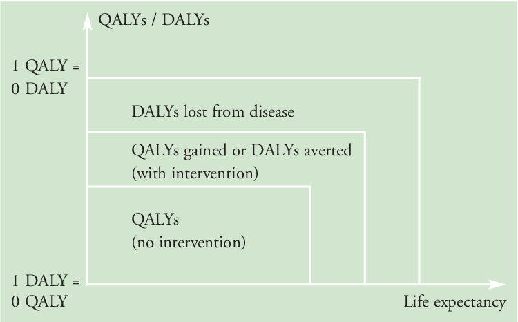

Fox-Rushby, Julia. “Disability-adjusted life years (DALYs) for decision-making?: an overview of the literature.” (2002).

## Priority setting in Denmark

- Historically: region-level prioritization based on general principles
- Danish Medicines Council: principled recommendations of coverage for pharmaceutical treatment
  - 2021: incorporation QALYs into assessment
- 2024: National Priority Council
  - Broader scope than DMC
  - Address demographic transition, labor constraints, regional and municipal variation

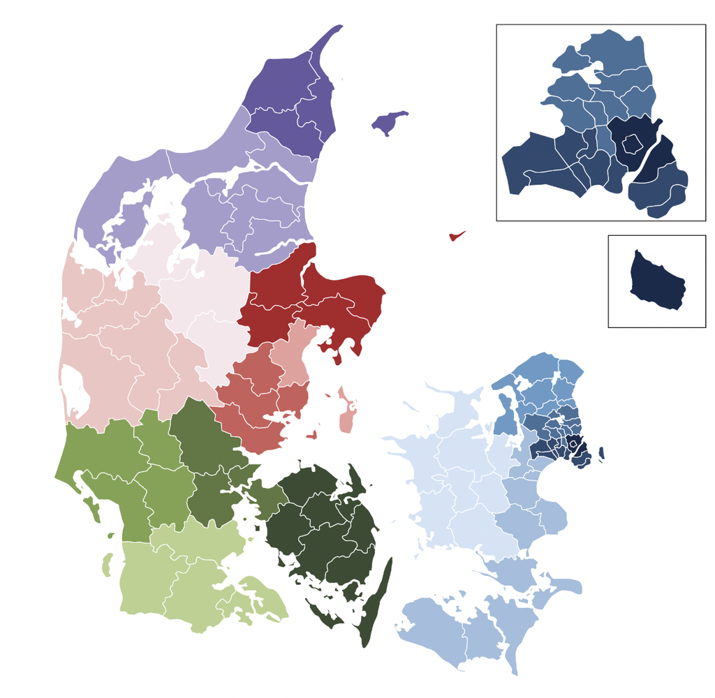

## Gap: non-health consequences of disease

- Economic, social, psychological, consequences of disease not captured in DALY/QALY
- Hypotheses:
  - These impacts are substantial, even in Denmark
  - These may not correlate to morbidity/mortality patterns by disease

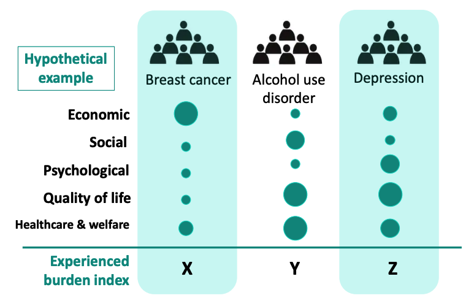

## Experienced burden of disease in Denmark

- We aim to estimate longitudinal economic and social impacts of hospital-diagnosed mental and physical disease across the Danish population from an individual perspective.
  - Comprehensive: population-level, inclusive
  - Long-term: 10 year follow-up, 27 years of data
  - Comparative: across and within diseases
  - Rigorous but not causal
    - Measurement bias for exposure
    - Confounding

## Identification

Exposure

- 1<sup>st</sup> hospital diagnosis of disease (inpatient, outpatient, psychiatric)
- Mental dx:
  - Depression, alcohol use disorder (AUD), eating disorders, bipolar disorder
- Somatic dx:
  - Breast cancer, stroke, spinal disc disorders, epilepsy, type 1 diabetes, inflammatory bowel disease (IBD)

Outcomes

- Part 1: personal disposable income
- Part 2:
  - Biological/adoptive parenthood
  - Household composition (children living in home)
- Part 3:
  - Total net wealth, all sources
  - Total savings and liquid assets
  - Property ownership (binary)
  - Relationship formation & dissolution

Red: 1<sup>st</sup> paper, income loss Green: 2<sup>nd</sup> paper, parenthood Orange: planned future work

## Study design & methods

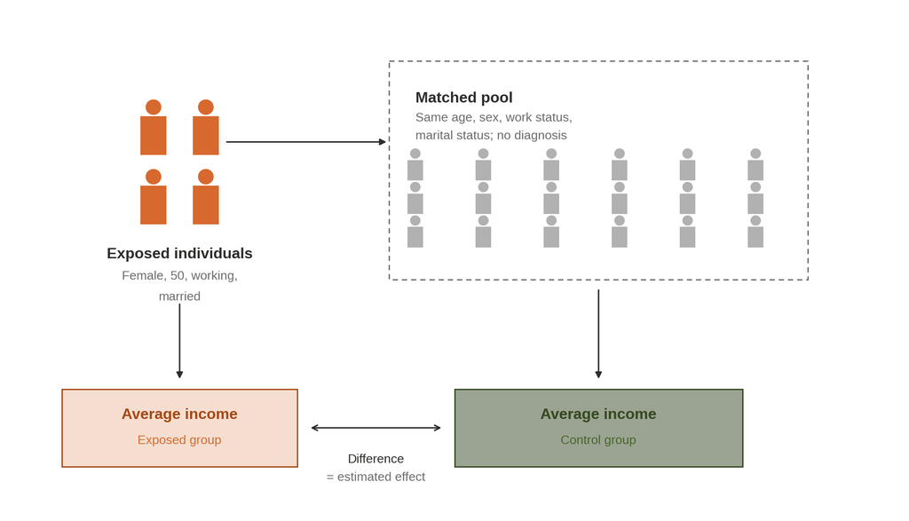

Matching variables:

Demographics

- Age, sex
- Marital status
- Household size

Socio-economics

- Baseline income quantile
- Educational attainment
- Labor market attachment

Baseline health

- Hospital contacts
- Charlson comorbidities

## Study design & methods

[figure not shown]

## Estimating income loss

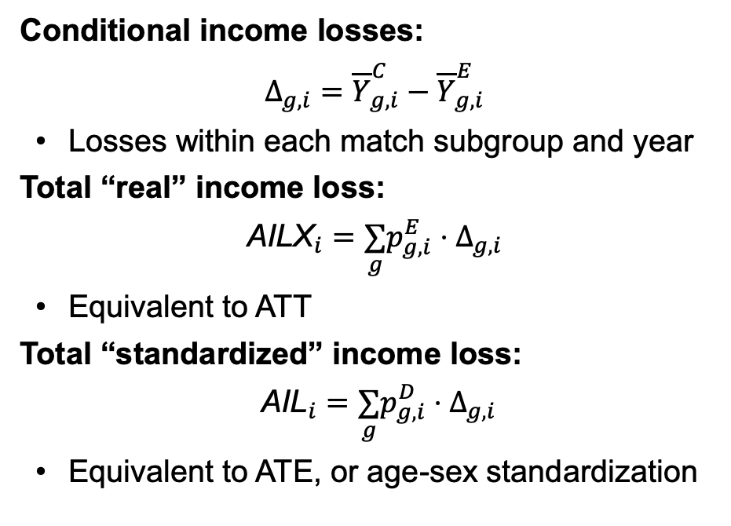

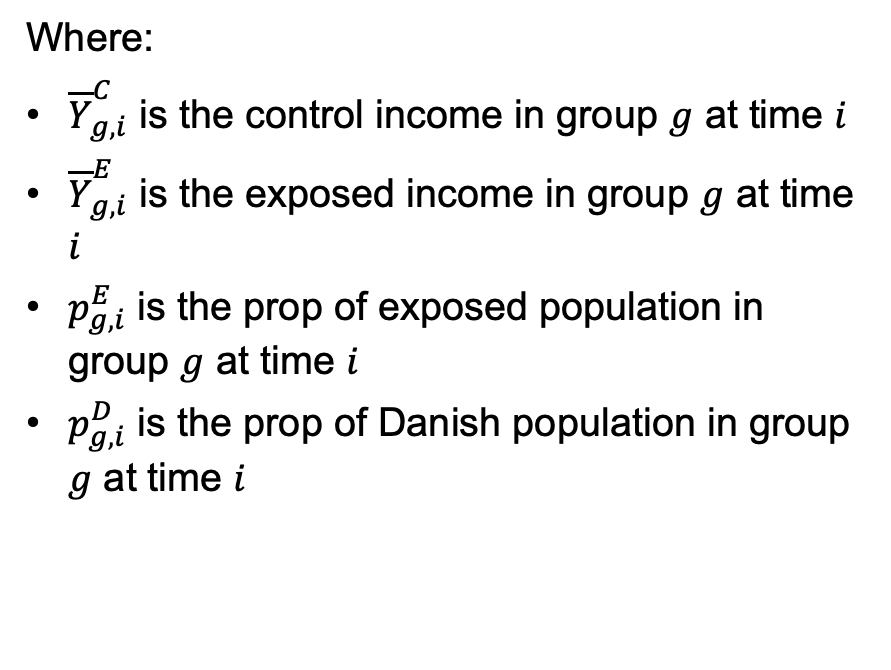

## Data management

| Step | Code processes | Rerun reasons | # reruns |
| --- | --- | --- | --- |
| Raw data prep | Recode categories Merge raw data Renaming | Rare | 8 |
| Matching | Define match groups by variable sets `df %>% mutate(group_id = cur_group_id(), .by = c(var1, var2))` | Any time I change a match variable | 28 |
| Merging future outcomes | Define exposed vs. control Merge 10 years of follow-up by match group Match group level aggregation | Change in exposure Change in match variable | 37 |
| Aggregation | Aggregate along subgroup combinations | Any time I need different aggregations | ~11 |

## Data management

- /code
  - /01_data_prep
    - 01_hospital.R
    - 02_populations.R
    - 03_family_variables.R
    - 04_data_prep_complete.R
  - /02_analysis
    - 01_matching.R
    - 02_identify_exposed.R
    - 03_run_estimation.R
    - 04_bootstrap.R
    - match_functions.R
  - /03_results
    - .....
- /data
  - /01_prepped
    - 20250401
    - 20251001
    - ...
  - /02_matched
    - 20250122
    - 20250123
    - ...
  - ...

## Data visualization

- Questions:
  - What do the different disease populations look like?
  - How do they differ?
  - What are the average outcomes of exposed, control groups?
  - What are the impacts of disease?
- Presentation:
  - Exploration vs. explanation

## Data visualization

- Questions:
  - What do the different disease populations look like?
  - How do they differ?
  - What are the average outcomes of exposed, control groups?
  - What are the impacts of disease?
- Presentation:
  - Exploration vs. explanation

## Disease population comparison – age at exposure

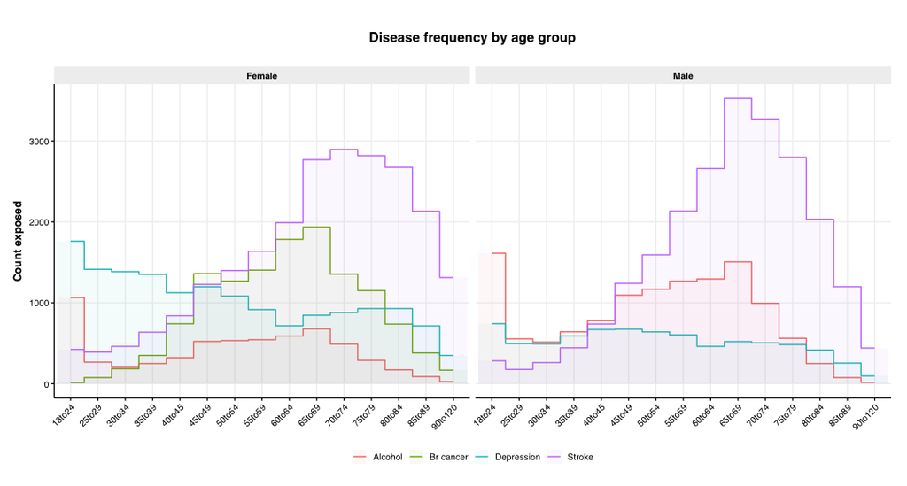

## Disease population comparison – diagnosis year

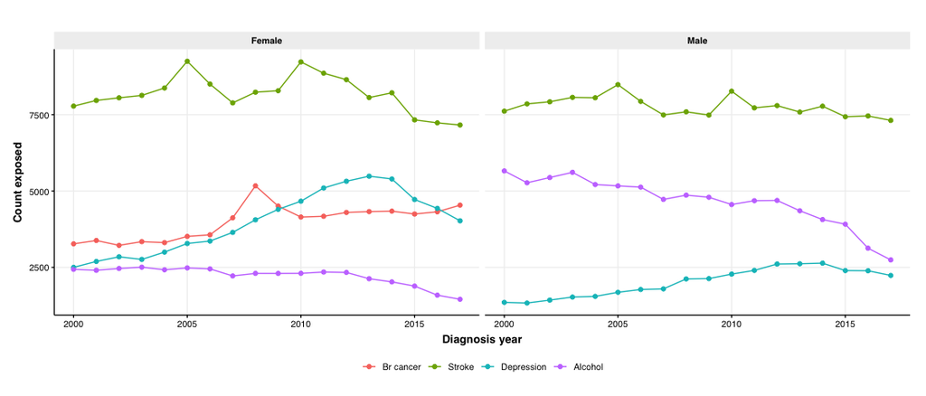

## Disease population comparison – labor status

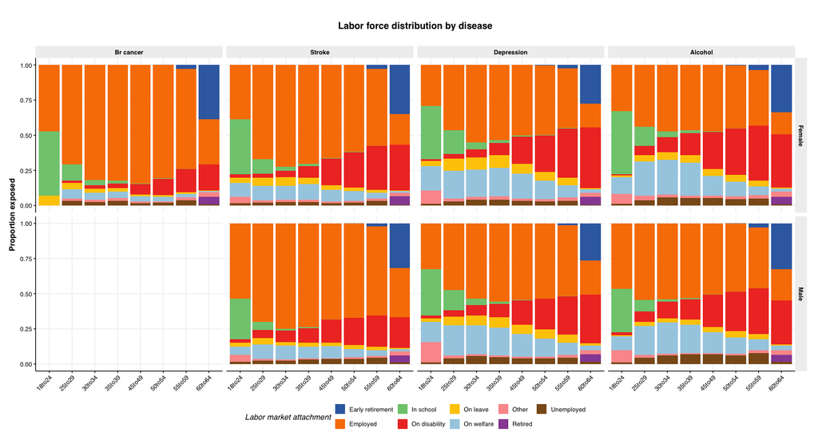

## Table 1

- Standard population characteristics table in health econ, epi papers
- Describes general population, your sample, your comparison
- Often grouped
- Useful for exploration and explanation

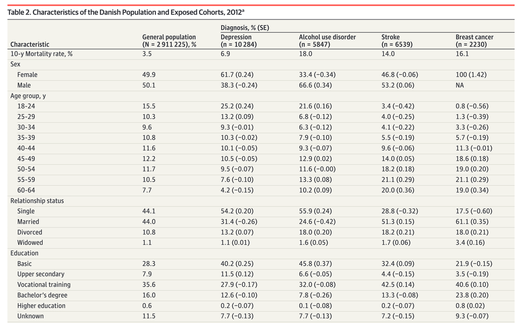

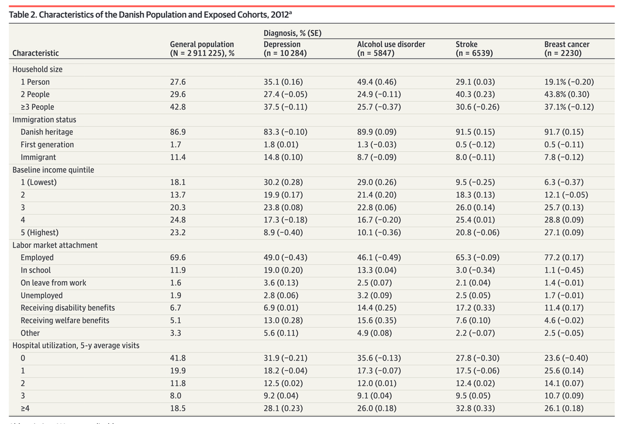

## Data visualization

- Questions:
  - What do the different disease populations look like?
  - How do they differ?
  - What are the average outcomes of exposed, control groups?
  - What are the impacts of disease?
- Presentation:
  - Exploration vs. explanation

## Exploration – shiny app

## Income losses continue 10 years after diagnosis, not explained by disease risk

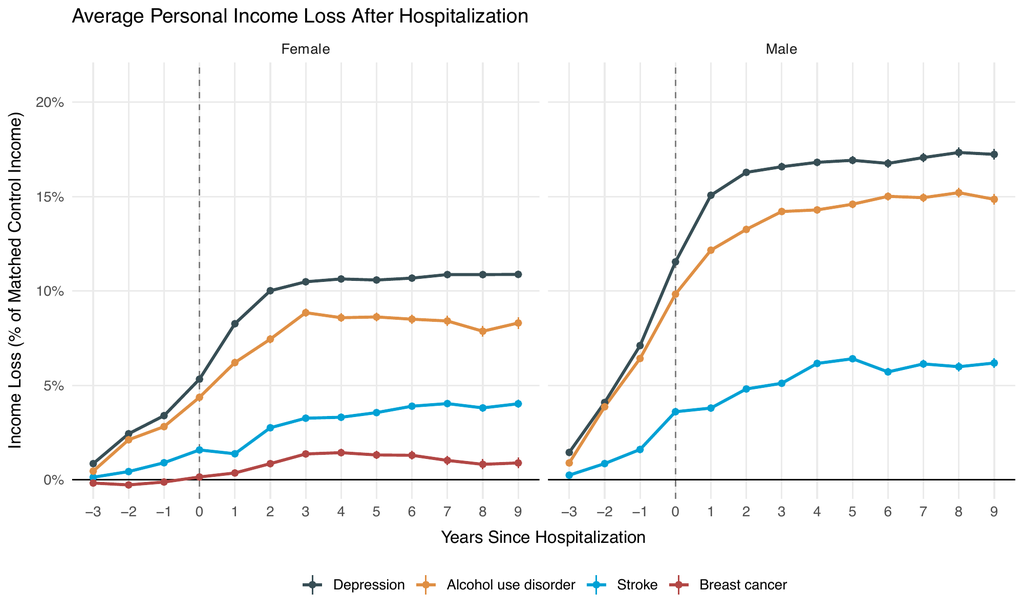

## Prime working ages, young males with depression most impacted

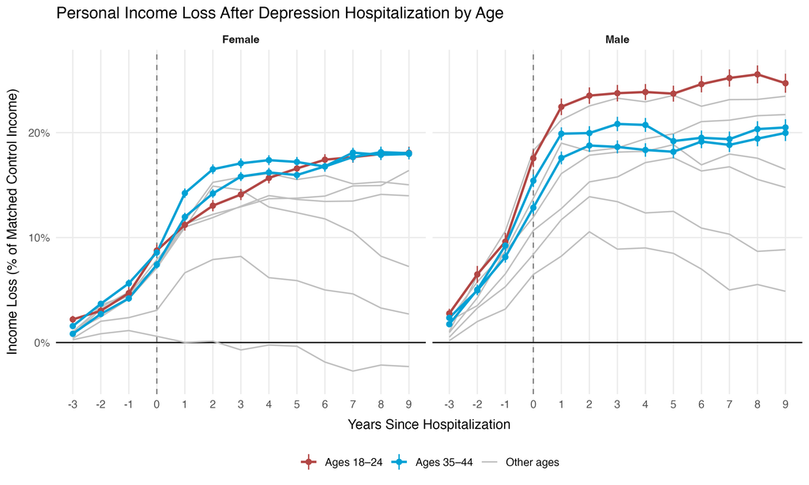

## Differential loss patterns across disease and demographics

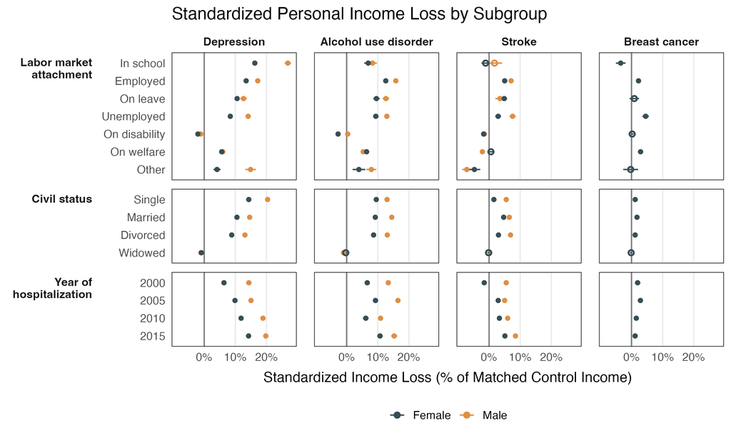

## Disease diagnosis and 10y parenthood rates

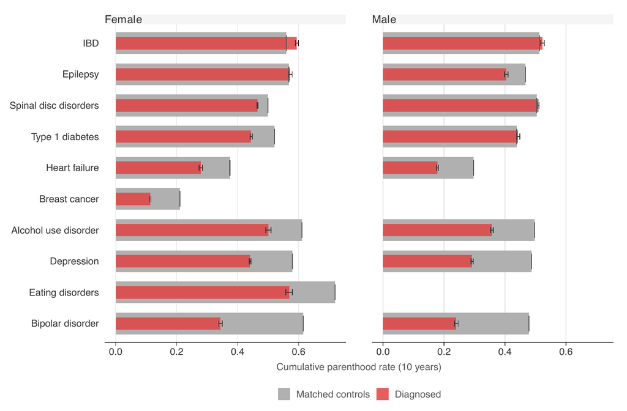

## Widening parenthood gap with time for many diseases

Cumulative 10-year parenthood rates differences over time

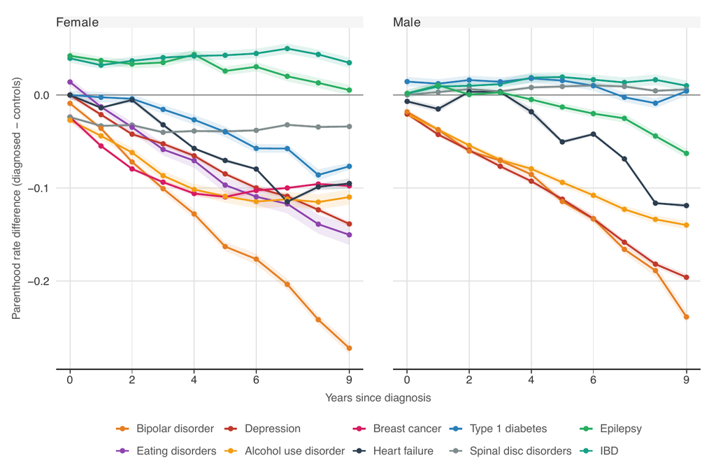

## Recap

- ExpBoD project – large data management project
  - Iterative
  - Large datasets
- Data interpretation
  - Table 1
  - Exploratory data visualization/analysis
  - Explanatory visualization